# 2025 Spring BIO 2100 Midterm Creation and Answers

## Instructions! Read this first.

The exam is open note, open course website, open class-related code repositories (mine and those you produced in class). However, you may not get external help ( from other students, directed internet searches, etc.). Please update the statement below to acknowledge these instructions (and that you can use git).

I, INSERT YOUR NAME HERE, promise to not seek external help on the exam. I understand any academic issues will result in a D or F on the exam or in the class and be reported to the Dean of Students. Infractions will also result in me being unable to obtain a letter of recommendation from the department for professional school applications.

The exam should be committed and pushed to github by Friday, 3/28/2025, at 1:15 PM. You can also commit and push along the way, but please mark your final commit (when you are finished) with the comment **Finished - ready to grade!.**

For all questions, the statement is based on what you might hear from a colleague (e.g., “How do I analyze this?”). This is like when you get a call to review a paper. Please answer questions succinctly but with necessary details on all required steps/concerns you might need to consider.

While the exam is based on a realistic scenario (with citations), some data and scenarios are fictional and contrived for the exam (i.e., don’t quote all this as fact!).

Good luck!

## Background

Joro spiders (*Trichonephila clavata*) are coming to New York!

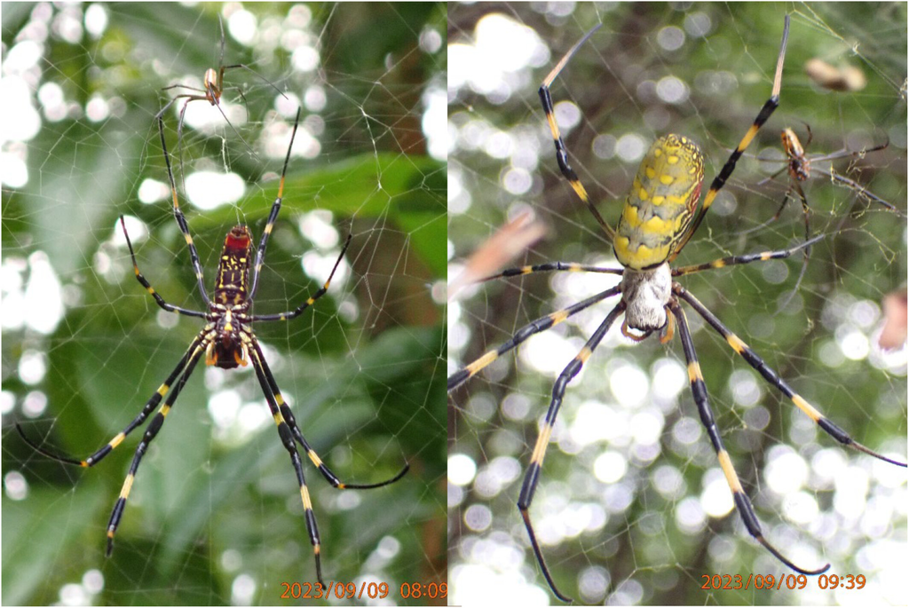

Image from Nelsen et al 2023

Originally from Asia, this spider was first observed in Georgia, USA, circa 2010. Recent modeling studies have suggested the species could thrive in New York (Nelsen et al. 2023).

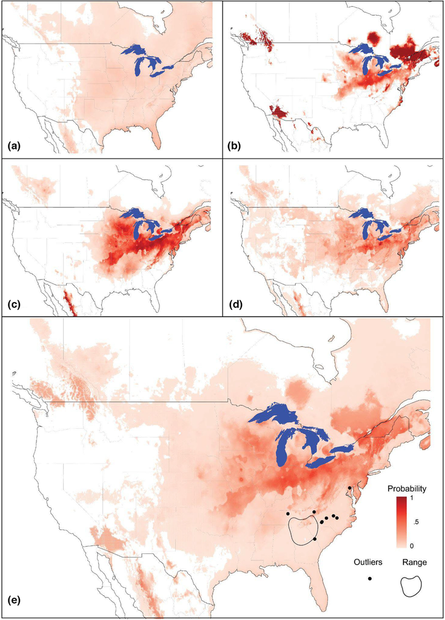

Species distribution model (SDM) predictions of Trichonephila clavata’s suitable range in North America based on its native Asian distribution: (a) General Linear Model, (b) General Additive Model, (c) Maxent, (d) Random Forest, and (e) Averaged prediction of all four models, calculated as an equally weighted average across all four primary models, including T. clavata’s introduced range as of December 2022. From Nelsen et al. 2023.

Given the pending (or already happened?) invasion, ecologists are studying the Joro spider more and more.

## 1

One explanation for the species rapid spread is the specific population that arrived in the United States differs from other populations of Joro spiders. For example, they may differ in their use of *ballooning*. Ballooning occurs when spiders deploy silk threads to catch air currents and disperse. In Joro spider populations in Japan, 18% of the hatchlings disperse via ballooning. An inital study of Joro spider hatchlings in Georgia indicated 22 out of 85 used ballooning. Does this suggest any difference in the use of ballooning by Joro spiders in Georgia?

Analyze the data. Make sure you include

- null hypothesis (1 point)
  - *the proportion of spiders balloowing is equal to .18*
- alternative hypothesis (1 point)
  - *the proportion of spiders balloowing is not equal to .18*
- explanation for test you will use (1.5 point)
  - *Since we have 2 outcomes and are comparing to a set proportion, I will use a binomial test.*
- results from statistical test (1 point)

```r
 binom.test(22,85,.18)
```

```
    Exact binomial test

data:  22 and 85
number of successes = 22, number of trials = 85, p-value = 0.06593
alternative hypothesis: true probability of success is not equal to 0.18
95 percent confidence interval:
 0.1698505 0.3652356
sample estimates:
probability of success
             0.2588235
```

- clear explanation of how results relate to your stated hypotheses (1.5 point)
  - *Given a p-value of .06, I fail to reject the null hypothesis.*

## 2

While presenting their work at a conference, another scientist shared they had done a similar but larger study. They found that 110 out of 425 hatchlings from Georgia used ballooning. What does their data indicate (you can use the same assumption of 18%)?

Analyze the data. Make sure you include

- null hypothesis (1 point)
  - *the proportion of spiders balloowing is equal to .18*
- alternative hypothesis (1 point)
  - *the proportion of spiders balloowing is not equal to .18*
- explanation for test you will use (1.5 point)
  - *Since we have 2 outcomes and are comparing to a set proportion, I will use a binomial test.*
- results from statistical test (1 point)

```r
 binom.test(110, 425, .18)
```

```
    Exact binomial test

data:  110 and 425
number of successes = 110, number of trials = 425, p-value = 5.021e-05
alternative hypothesis: true probability of success is not equal to 0.18
95 percent confidence interval:
 0.2178109 0.3032305
sample estimates:
probability of success
             0.2588235
```

## 3

A new student is confused when comparing these studies. Both have the same signal for ballooning.

### a

What is the signal for ballooning rate in both datasets?

```r
110/425
```

```
[1] 0.2588235
```

```r
22/85
```

```
[1] 0.2588235
```

*Both samples shows a signal (proportion ballooning) of .258 #*

### b

However, they differ in p-value. Why? In answering this make sure you can explain what a p-value is.

*The samples differ in associated p-values due to sample size. P-value is the probability of getting the signal you observed or something more extreme if the null hypothesis is true and you sampled the population multiple times.*

## 4

The larger study also recorded hatchling sex (recorded as male or female). Data is shown below

Spider hatchling gender and ballooning

[output not shown]

How would you analyze the data to determine if sex impacts ballooning? Make sure you include

- null hypothesis (1 point)
  - *ballooning is not continget on sex*
- alternative hypothesis (1 point)
  - *ballooning is continget on sex*
- explanation for test you will use (1.5 point)
  - *I will use a $\chi^2$ test because I am comparing proportions among groups (table style data)*
- results from statistical test (1 point)

```r
chisq.test(matrix(c(54, 56, 150,165), nrow = 2, byrow = T))
```

```
    Pearson's Chi-squared test with Yates' continuity correction

data:  matrix(c(54, 56, 150, 165), nrow = 2, byrow = T)
X-squared = 0.024079, df = 1, p-value = 0.8767
```

- clear explanation of how results relate to your stated hypotheses (1.5 point)
  - *Since the p value is greater than 0.05, we fail to reject the null hypothesis*

## 5

Another, related hypothesis is that the invasive spiders have smaller hatchlings. Weight data was collected from a population in Georgia and two populations in Asia (Japan and Korea). It can be loaded using. Weight is in mg.

```r
set.seed(29)
spider_mass <- data.frame(population = c(rep("Georgia", 30), rep("Japan", 29), rep("Korea", 30)), mass_mg = c(rnorm(30, .25, .05), rnorm(30, .35, .07), rnorm(29, .32, .04)))
write.csv(spider_mass, "spider_mass.csv", row.names = F)
rm(spider_mass)
```

```r
spider_mass <- read.csv("spider_mass.csv", stringsAsFactors = T)
```

How would you analyze the data. Make sure you include

- null hypothesis (1 point)
  - *the means of the three populations are equal*
- alternative hypothesis (1 point)
  - *the means of the three populations are not equal*
- explanation for test you will use (1.5 point)
  - *Given we are comparing means among 3 groups, I will use an ANOVA*
- results from statistical test (1 point)
  - *First I build the model and test assumptions*

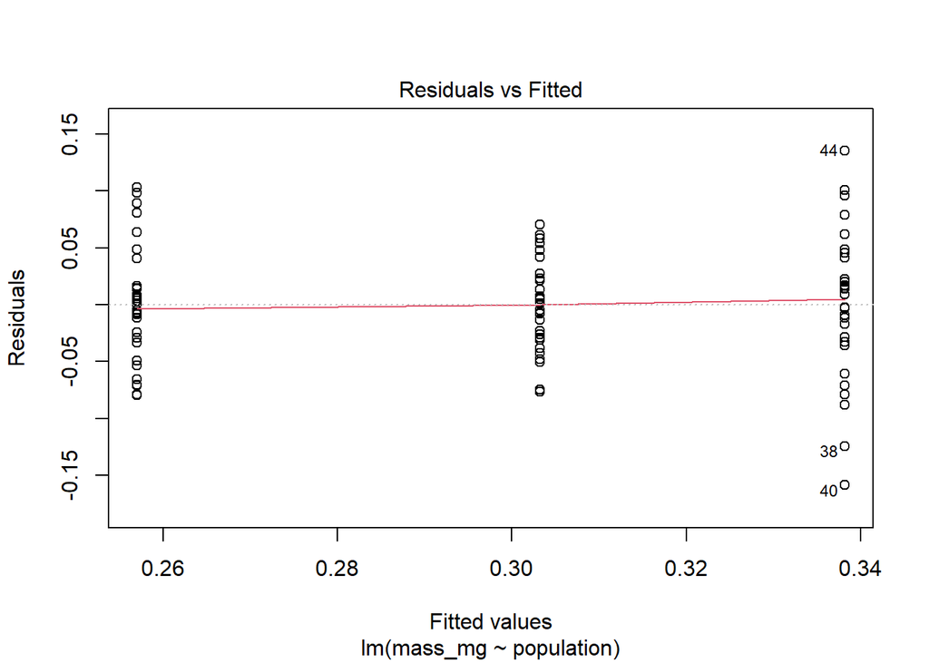

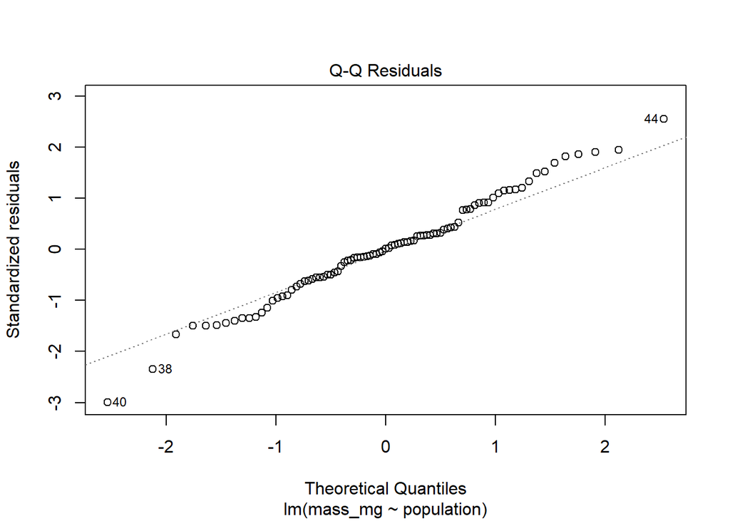

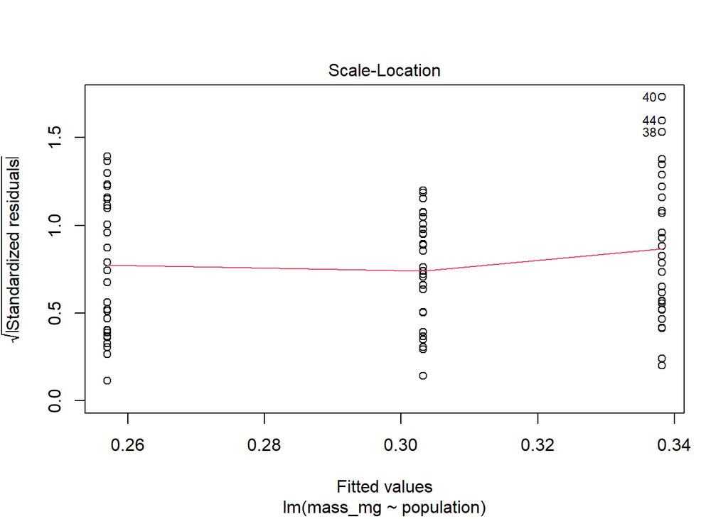

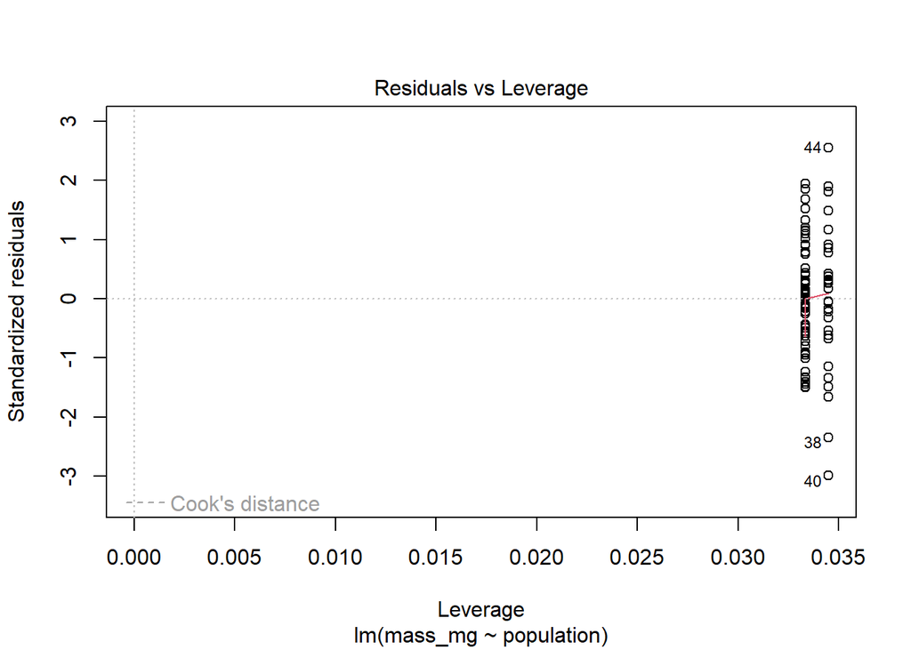

```r
spider_mass_model <- lm(mass_mg~population, spider_mass)
plot(spider_mass_model)
```

[output not shown]

```r
library(car)
Anova(spider_mass_model, type="III")
```

```
Anova Table (Type III tests)

Response: mass_mg
             Sum Sq Df F value    Pr(>F)
(Intercept) 1.98157  1  682.94 < 2.2e-16 ***
population  0.09790  2   16.87 6.595e-07 ***
Residuals   0.24953 86
---
Signif. codes:  0 '***' 0.001 '**' 0.01 '*' 0.05 '.' 0.1 ' ' 1
```

[output not shown]

```r
library(multcomp)
spider_mass_compare <- glht(spider_mass_model,  linfct = mcp(population = "Tukey"))
summary(spider_mass_compare)
```

```
     Simultaneous Tests for General Linear Hypotheses

Multiple Comparisons of Means: Tukey Contrasts


Fit: lm(formula = mass_mg ~ population, data = spider_mass)

Linear Hypotheses:
                     Estimate Std. Error t value Pr(>|t|)
Japan - Georgia == 0  0.08115    0.01403   5.785  < 0.001 ***
Korea - Georgia == 0  0.04622    0.01391   3.323  0.00375 **
Korea - Japan == 0   -0.03493    0.01403  -2.490  0.03866 *
---
Signif. codes:  0 '***' 0.001 '**' 0.01 '*' 0.05 '.' 0.1 ' ' 1
(Adjusted p values reported -- single-step method)
```

Plot the data from question 5.

*Several options here*

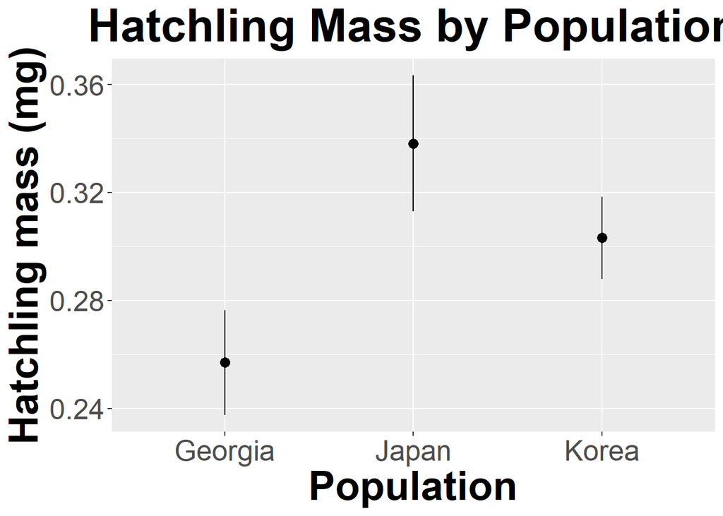

```r
library(Rmisc)
library(ggplot2)
spider_summary <- summarySE(spider_mass, measurevar="mass_mg", groupvars="population")
ggplot(spider_summary, aes(x=population, y=mass_mg)) +
    geom_point(size=3) +
    geom_errorbar(aes(ymin=mass_mg - ci, ymax=mass_mg + ci), width=0) +
    ylab("Hatchling mass (mg)") +
    xlab("Population") +
    ggtitle("Hatchling Mass by Population") +
    theme(axis.title.x = element_text(face="bold", size=28),
          axis.title.y = element_text(face="bold", size=28),
          axis.text.x = element_text(size=20),
          axis.text.y = element_text(size=20),
          plot.title = element_text(hjust=0.5, face="bold", size=32))
```

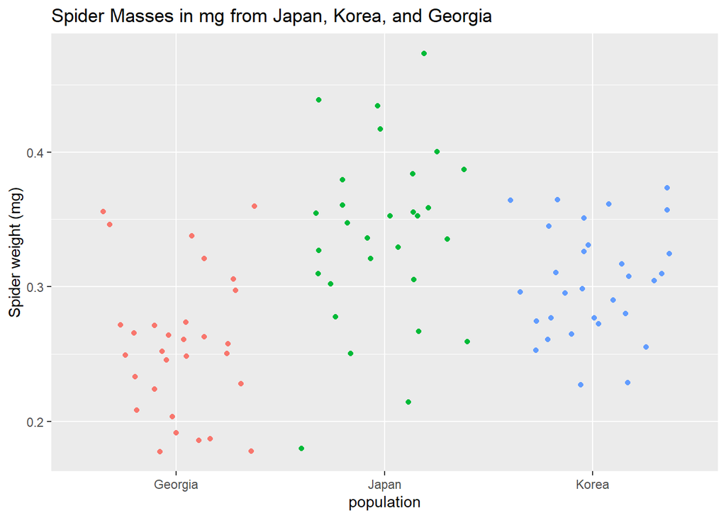

```r
ggplot(spider_mass, aes(y=mass_mg, x=population, color=population)) +
  geom_jitter() +
  labs(title="Spider Masses in mg from Japan, Korea, and Georgia",
       y= "Spider weight (mg)",
       x= "population")+
  guides(color=F)
```

## References

Nelsen, David R., Aaron G. Corbit, Angela Chuang, John F. Deitsch, Michael I. Sitvarin, and David R. Coyle. 2023. “Veni, Vidi, Vici? Future Spread and Ecological Impacts of a Rapidly Expanding Invasive Predator Population.” *Ecology and Evolution* 13 (11): e10728. https://doi.org/10.1002/ece3.10728.